# Statistical Thinking Ch. 5 Practice

Dag Tanneberg

04/13/2019

```r
library("tidyverse")
library("rethinking")
```

# Easy

## 5E2

Write down a multiple regression to evaluate the claim: *Animal diversity is linearly related to latitude, but only after controlling for plant diversity.* You just need to write down the model definition.

$\text{Animal Diversity} = \alpha + \beta_1 \text{Latitude} + \beta_2 \text{Plant Diversity} + e$

## 5E3

Write down a multiple regression to evaluate the claim: *Neither amount of funding nor size of laboratory is by itself a good predictor of time to PhD degree; but together these variables are both positively associated with time to degree*. Write down the model definition and indicate which side of zero each slope parameter should be on.

1. $\text{Time to PhD} = \alpha + \beta_1 \text{Funding}$
2. $\text{Time to PhD} = \alpha + \beta_2 \text{Lab Size}$
3. $\text{Time to PhD} = \alpha + \beta_1 \text{Funding} + \beta_2 \text{Lab Size}$

## 5E4

Suppose you have a single categorical predictor with 4 levels (unique values), labeled A, B, C and D. Let $A_i$ be an indicator variable that is 1 where case $i$ is in category A. Also suppose $B_i , C_i , and D_i$ for the other categories. Now which of the following linear models are inferentially equivalent ways to include the categorical variable in a regression? Models are inferentially equivalent when it’s possible to compute one posterior distribution from the posterior distribution of another model.

1. $\mu_i = \alpha + \beta_A A_i + \beta_B B_i + \beta_C B_i$
2. $\mu_i = \alpha + \beta_A A_i + \beta_B B_i + \beta_C C_i + \beta_D D_i$
3. $\mu_i = \alpha + \beta_B B_i + \beta_C C_i + \beta_D D_i$
4. $\mu_i = \alpha_A A_i + \alpha_B B_i + \alpha_C C_i + \alpha_D D_i$
5. $\mu_i = \alpha_A(1 - B_i - C_i - D_i) + \alpha_B B_i \alpha_C C_i + \alpha_D D_i$

Model 1 is inferentially equivalent to Model 3. Each reflects a mean adjustment model for $\mu$, but they differ on the chosen baseline. In Model 1 $\alpha = \beta_D$ and in Model 3 $\alpha = \beta_A$. Model 2, in contrast, is not identified because it includes all indicator variables simultaneously. Their effects are perfectly collinear. Dropping the intercept $\alpha$ would solve the problem and transform the Model 2 into Model 4.

Models 4 and 5 are inferentially equivalent because $(1 - B_i - C_i - D_i) = 1 \iff B_i = C_i = D_i = 0$. This observation $i$ must therefore be in category A, and thus: $\alpha_A(1 - B_i - C_i - D_i) = \alpha_A A_i$.

# Medium

## 5M1.

Invent your own example of a spurious correlation. An outcome variable should be correlated with both predictor variables. But when both predictors are entered in the same model, the correlation between the outcome and one of the predictors should mostly vanish (or at least be greatly reduced).

Electoral turnout in democracies declines over time and increases in the presence pre-electoral coalitions. However, pre-electoral coalitions became rarer over time as well. Hence, when controlling for time, i.e. detrending the data, the association between turnout and pre-electoral coalitions turns out spurious.

## 5M2.

Invent your own example of a masked relationship. An outcome variable should be correlated with both predictor variables, but in opposite directions. And the two predictor variables should be correlated with one another.

Parliamentary government systems are directly associated with stable democracy. At the same time, a history of military intervention into politics is indirectly associated with stable democracy, e.g., Latin America. Usually, parliamentary democracies do not have a history of military intervention into politics.

## 5M3.

It is sometimes observed that the best predictor of fire risk is the presence of firefighters. States and localities with many firefighters also have more fires. Presumably firefighters do not cause fires. Nevertheless, this is not a spurious correlation. Instead fires cause firefighters. Consider the same reversal of causal inference in the context of the divorce and marriage data. How might a high divorce rate cause a higher marriage rate? Can you think of a way to evaluate this relationship, using multiple regression?

Assume some policy grants cheap loans to newly weds, regardless of how often individuals were already married. Hence, individuals have strong incentive to get married again should they divorce their partner.

5M4.

In the divorce data, States with high numbers of Mormons (members of The Church of Jesus Christ of Latter-day Saints, LDS) have much lower divorce rates than the regression models expected. Find a list of LDS population by State and use those numbers as a predictor variable, predicting divorce rate using marriage rate, median age at marriage, and percent LDS population (possibly standardized). You may want to consider transformations of the raw percent LDS variable.

```r
data(WaffleDivorce)
lds <- read.csv2("~/github/learning/rethinking/lds_pop.csv", stringsAsFactors = FALSE)
lds <- mutate(lds, lds_per = str_replace(lds_per, "%", "")) %>%
    mutate(lds_per = str_replace(lds_per, ",", ".")) %>%
    mutate(lds_per = as.numeric(lds_per))
names(WaffleDivorce) <- str_to_lower(names(WaffleDivorce))
WaffleDivorce <- left_join(WaffleDivorce, lds, by = "location")
summary(WaffleDivorce$lds_per)
```

```
##    Min. 1st Qu.  Median    Mean 3rd Qu.    Max.
##  0.3700  0.6025  0.8200  3.4260  1.4425 67.7000
```

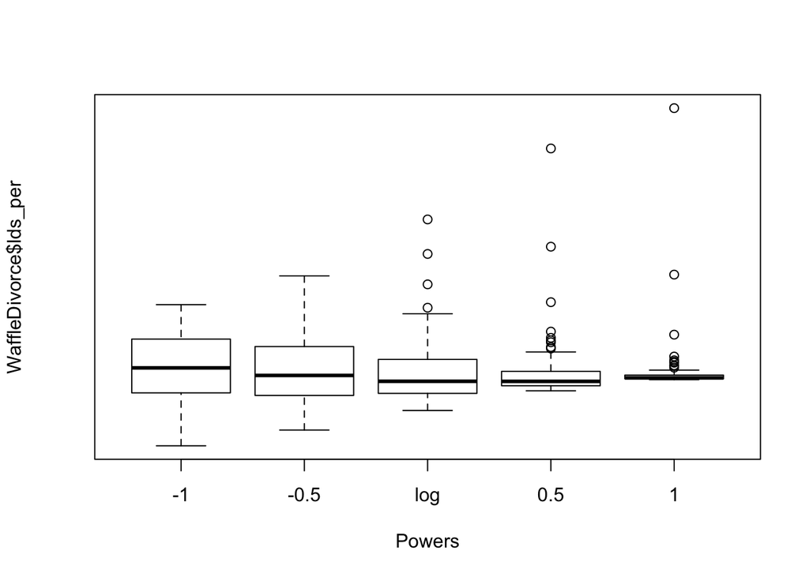

```r
car::symbox(WaffleDivorce$lds_per)
```

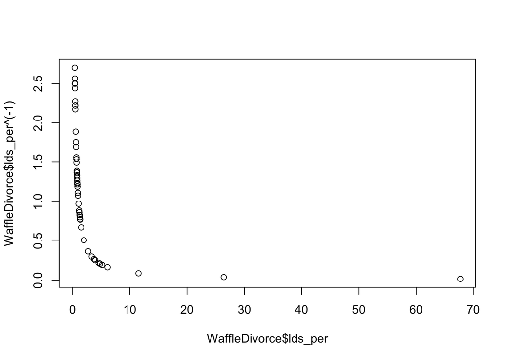

```r
plot(WaffleDivorce$lds_per, WaffleDivorce$lds_per^(-1))
```

```r
WaffleDivorce <- mutate(WaffleDivorce, inv_lds_per = lds_per^(-1))

stan_data <- list(
    y = WaffleDivorce$divorce,
    X = cbind(1, mar = WaffleDivorce$marriage,
        age = WaffleDivorce$medianagemarriage, lds = WaffleDivorce$inv_lds_per
    ),
    N = nrow(WaffleDivorce),
    K = 4
)
stan_model <- "
    data {
        int<lower = 0> N;
        int<lower = 1> K;
        matrix[N, K] X;
        vector[N] y;
    }
    parameters {
        vector[K] beta;
        real<lower=0> sigma;
    }
    model {
        y ~ normal(X * beta, sigma);
        beta ~ normal(0, 1);
        sigma ~ exponential(1);
    }

"
stan_fit <- stan(model_code = stan_model, data = stan_data)
```

```
## [1] 0.116
```

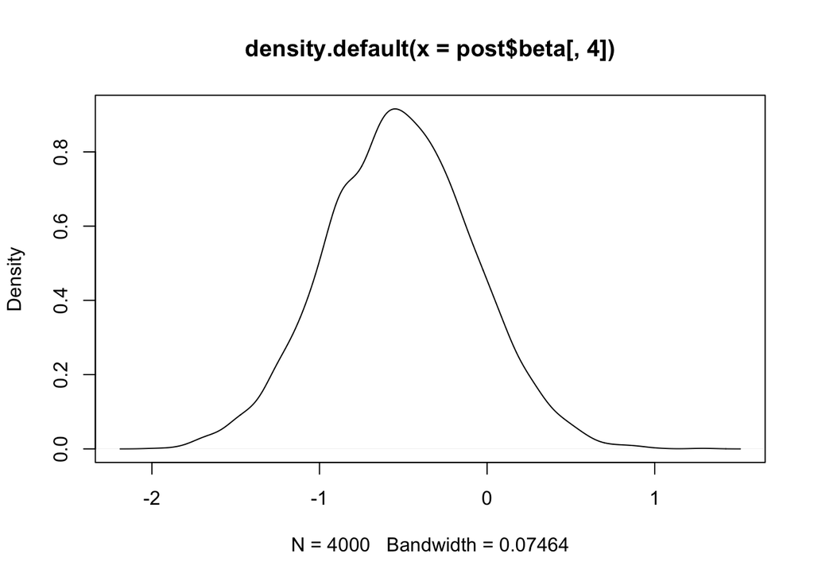

```r
post <- rstan::extract(stan_fit)
mean(post$beta[, 4] > 0); plot(density(post$beta[, 4]))
```